# Cap1

## **Título**: Inicio en Twiter

**Cuaderno de herramientas necesarias**

**Autor**: Daniel Ivan Medina Barreras

**Fecha**: 20200730

**Referencia**: cap1.ipynb

**Descripción** : Se realiza una pequeña demo de las herramientas necesarias

[figure not shown]

# Twitter

## Contenidos

- Introduccion
  - Analisis de datos de Twitter con python
- Demo gensim
- Demo JSON
- Demo matplotlib
- Demo networkx
- Demo Numpy
- Demo sklearn

# 2. demo gensim 📕

**Instalación**

> `conda install -c anaconda gensim`

**Descripción**

**Gensim** es una biblioteca de Python para modelado de temas, indexación de documentos y recuperación de similitudes con grandes corpus. El público objetivo es la comunidad de procesamiento del lenguaje natural (PNL) y recuperación de información (IR).

**Link**

[gensim](https://radimrehurek.com/gensim/auto_examples/index.html)

```python
from gensim.summarization import summarize
import sys

fname = sys.argv[0]

with open(fname, 'r') as f:
    content = f.read()
    summary = summarize(content, split=True, word_count=100)
    for i, sentence in enumerate(summary):
        print("%d) %s" % (i+1, sentence))
```

```
1) """Entry point for launching an IPython kernel.
2) This is separate from the ipykernel package so we can avoid doing imports until
3) after removing the cwd from sys.path.
4) import sys
5) if __name__ == '__main__':
6) # Remove the CWD from sys.path while we load stuff.
7) # This is added back by InteractiveShellApp.init_path()
8) if sys.path[0] == '':
9) del sys.path[0]
10) from ipykernel import kernelapp as app
11) app.launch_new_instance()
```

# 3. Demo JSON 📘

**Instalación**

> Viene con la instalacon de PYTHON

**Descripción**

Python tiene este paquete incorporado llamado json, que puede usarse para trabajar con datos JSON.

**JSON** (JavaScript Object Notation), especificado por RFC 7159 (que obsoleto RFC 4627) y por ECMA-404, es un formato de intercambio de datos ligero inspirado en la sintaxis literal de objetos JavaScript (aunque no es un subconjunto estricto de JavaScript 1).

json expone una API familiar para los usuarios de los módulos estándar de mariscal y encurtidos de la biblioteca.

**Link**

[JSON](https://docs.python.org/3/library/json.html)

```python
import json

user_json = '{"user_id": "1", "name": "Marco"}'
user_data = json.loads(user_json)
print(user_data['name'])
```

```
Marco
```

Estructura

```
Output:
    {
        "user_id": "1",
        "name": "Marco",
        "likes": [
            "Python",
            "Data Mining"
        ]
    }
```

```python
# Output: Marco
user_data['likes'] = ['Python', 'Data Mining']
user_json = json.dumps(user_data, indent=4)
print(user_json)
```

```
{
    "user_id": "1",
    "name": "Marco",
    "likes": [
        "Python",
        "Data Mining"
    ]
}
```

### 4. **Demo matplotlib 🖼️**

**Instalación**

> `conda install -c conda-forge -y matplotlib`

**Descripción**

Matplotlib es una biblioteca para la generación de gráficos a partir de datos contenidos en listas o arreglos en el lenguaje de programación Python y su extensión matemática NumPy.

Por medio del comando mágico `%matplotlib inline` se indica que los despliegues gráficos de la biblioteca matplotlib se despliegan en el cuaderno Jupyter directamente.

**Link**

[Matplotlib](https://matplotlib.org/)

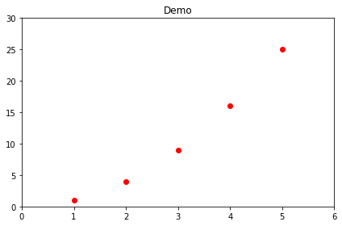

```python
import matplotlib.pyplot as plt
import numpy as np

# plot y = x^2 with red dots
x = np.array([1, 2, 3, 4, 5])
y = x * x
plt.title('Demo')
plt.plot(x, y, 'ro')
plt.axis([0, 6, 0, 30])
plt.savefig('./images/demo_plot.png')
plt.tight_layout()
```

# 5. Demo networkx 🕸️

**Instalación**

> `conda install -c anaconda networkx`

**Descripción**

NetworkX es un paquete de Python para la creación, manipulación y estudio de la estructura, dinámica y funciones de redes complejas.

**Link**

[networkx](https://networkx.github.io/)

```python
import networkx as nx
from datetime import datetime

g = nx.Graph()
g.add_node('Anu', name='Anu', age=30)
g.add_node("Peter", name= 'Peter', age= 35)
g.add_node("Mary", name='Mary', age= 31)
g.add_node("Lucy", name= 'Lucy', age= 19)

g.add_edge("John", "Mary", type= 'friend', since= datetime.today())
g.add_edge("John", "Peter", type= 'friend', since= datetime(1990, 7, 30))
g.add_edge("Mary", "Lucy", type= 'friend', since= datetime(2010, 8, 10))
```

```python
g.nodes()
```

```
NodeView(('Anu', 'Peter', 'Mary', 'Lucy', 'John'))
```

```python
g.edges()
```

```
EdgeView([('Peter', 'John'), ('Mary', 'John'), ('Mary', 'Lucy')])
```

```python
g.has_edge("Lucy", "Mary")
```

```
True
```

## 6. Demo numpy 🔢

**Instalación**

> `conda install -c anaconda -y numpy`

**Descripción**

Numpy es una biblioteca para el lenguaje de programación Python que (entre otras cosas) brinda soporte para grandes matrices multidimensionales.

¿Por qué es eso importante? Usando NumPy, podemos expresar imágenes como matrices multidimensionales.

Representar imágenes como matrices NumPy no solo es computacional y eficiente en el uso de recursos, sino que muchas otras bibliotecas de procesamiento de imágenes y aprendizaje automático también usan representaciones de matrices NumPy. Además, al usar las funciones matemáticas de alto nivel incorporadas de NumPy, podemos realizar rápidamente análisis numéricos en una imagen.

**Link**

[Numpy](https://numpy.org/)

```python
from timeit import timeit
import numpy as np

setup_sum = 'data = list(range(10000))'
setup_np = 'import numpy as np;'
setup_np += 'data_np = np.array(list(range(10000)))'

run_sum = 'result = sum(data)'
run_np = 'result = np.sum(data_np)'

time_sum = timeit(run_sum, setup=setup_sum, number=10000)
time_np = timeit(run_np, setup=setup_np, number=10000)

print("Time for built-in sum(): {}".format(time_sum))
print("Time for np.sum(): {}".format(time_np))
```

```
Time for built-in sum(): 0.7894068999999999
Time for np.sum(): 0.08401410000000009
```

## 7. Demo sklearn 💡

**Instalación**

> `conda install scikit-learn`

**Descripción**

Scikit-learn es una biblioteca de aprendizaje automático gratuita para Python. Cuenta con varios algoritmos como máquina de vectores de soporte, bosques aleatorios y vecinos k, y también admite bibliotecas numéricas y científicas de Python como NumPy y SciPy.

**Link**

[sklearn](https://scikit-learn.org/stable//)

```python
from sklearn import datasets
from sklearn.cluster import KMeans
import matplotlib.pyplot as plt
```

### Load the data

```python
iris = datasets.load_iris()
X = iris.data
petal_length = X[:, 2]
petal_width = X[:, 3]
true_labels = iris.target
```

### Apply KMeans clustering

```python
estimator = KMeans(n_clusters=3)
estimator.fit(X)
predicted_labels = estimator.labels_
```

### Color scheme definition: red, yellow and blue

```python
color_scheme = ['r', 'y', 'b']
```

### Markers definition: circle, "x" and "plus"

```python
marker_list = ['x', 'o', '+']
```

### Assign colors/markers to the predicted labels

```python
colors_predicted_labels = [color_scheme[lab] for lab in predicted_labels]
markers_predicted = [marker_list[lab] for lab in predicted_labels]
```

### Assign colors/markers to the true labels

```python
colors_true_labels = [color_scheme[lab] for lab in true_labels]
markers_true = [marker_list[lab] for lab in true_labels]
```

### Plot and save the two scatter plots

```
['setosa' 'versicolor' 'virginica']
```

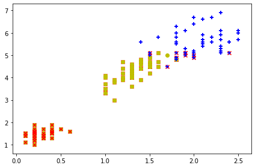

```python
for x, y, c, m in zip(petal_width,
                        petal_length,
                        colors_predicted_labels,
                        markers_predicted):
    plt.scatter(x, y, c=c, marker=m)
plt.savefig('./images/iris_clusters.png')

for x, y, c, m in zip(petal_width,
                        petal_length,
                        colors_true_labels,
                        markers_true):
    plt.scatter(x, y, c=c, marker=m)
plt.tight_layout()
plt.savefig('./images/iris_true_labels.png')

print(iris.target_names)
```